# Empirical Exercise

LeTao Wang

2017/4/2

## Answers

### a.

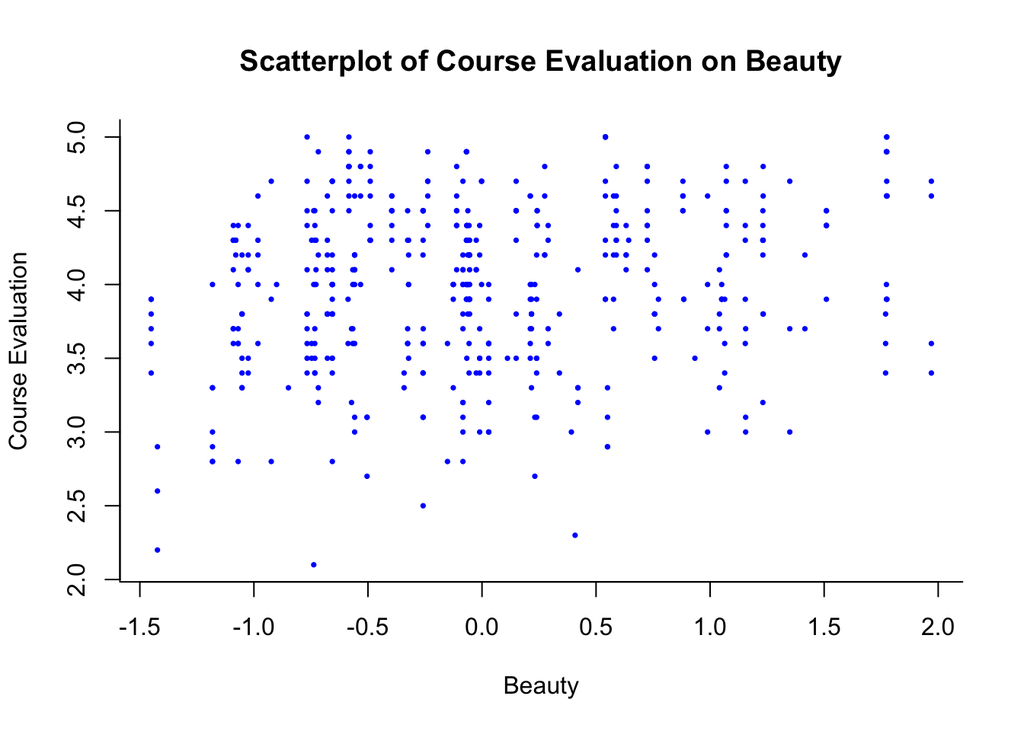

```r
library(foreign)
mydata<-read.dta("/Users/wangletao/Desktop/college/TeachingRatings/TeachingRatings.dta")
df<-mydata[c("course_eval","beauty")]
plot(df$beauty, df$course_eval,col="blue",pch=16,cex=0.5,bty="l",
     main= "Scatterplot of Course Evaluation on Beauty",
     xlab= "Beauty",ylab= "Course Evaluation")
```

We can compute the correlation coefficient between the two variables, using the function `cor`, to see the relationship.

```r
cor(df$beauty,df$course_eval)
```

```
## [1] 0.1890391
```

Apparently, the relationship between the two variables is small.

### b.

Using `lm(course_eval~beauty,…)` to construct a regression.

```r
mod<-lm(course_eval~beauty,data=df)
summary(mod)
```

```
##
## Call:
## lm(formula = course_eval ~ beauty, data = df)
##
## Residuals:
##      Min       1Q   Median       3Q      Max
## -1.80015 -0.36304  0.07254  0.40207  1.10373
##
## Coefficients:
##             Estimate Std. Error t value Pr(>|t|)
## (Intercept)  3.99827    0.02535 157.727  < 2e-16 ***
## beauty       0.13300    0.03218   4.133 4.25e-05 ***
## ---
## Signif. codes:  0 '***' 0.001 '**' 0.01 '*' 0.05 '.' 0.1 ' ' 1
##
## Residual standard error: 0.5455 on 461 degrees of freedom
## Multiple R-squared:  0.03574,    Adjusted R-squared:  0.03364
## F-statistic: 17.08 on 1 and 461 DF,  p-value: 4.247e-05
```

From the table:

- Estimated Intercept=3.998 (4)
- Estimated Slope=0.133

The linear regression equation:
$$\hat{Y_i} = 3.998 +0.133 X_i + u_i, \text{ for } i = 1, \ldots, n$$

Based on the scatterplot in **a**, we add the regression line:

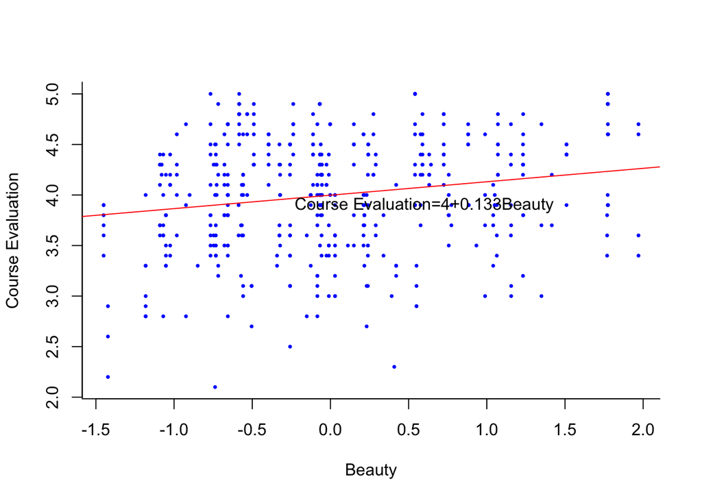

```r
intercept<-coef(mod)[1]
slope<-coef(mod)[2]
texteq<-paste("Course Evaluation=",round(intercept,1),"+",round(slope,3),"Beauty",sep="")
plot(df$beauty,df$course_eval,col="blue",pch=16,cex=0.5,bty="l",
     xlab="Beauty",ylab="Course Evaluation")
abline(intercept,slope,col="red")
text(0.6,3.9,texteq,cex.lab = 0.5, font.lab = 3)
```

```r
summary(df)
```

```
##   course_eval        beauty
##  Min.   :2.100   Min.   :-1.45049
##  1st Qu.:3.600   1st Qu.:-0.65627
##  Median :4.000   Median :-0.06801
##  Mean   :3.998   Mean   : 0.00000
##  3rd Qu.:4.400   3rd Qu.: 0.54560
##  Max.   :5.000   Max.   : 1.97002
```

According to the summary of *df* and *mod*, we can conclude that estimated intercept equals to the sample mean of Course_Eval.

Because:
$$\overline{Course\ Evaluation}= \hat\beta_0 + \hat\beta_1\overline{Beauty}$$

and $\overline{Beauty}$=0.00 (According to the summary of *df*) =>$\overline{Course\ Evaluation}$=3.998+0.133*0=3.998=$\hat{intercept}$

### c.

Compute the standard deviation of beauty:

```r
std<-sapply(df,sd)
print(std)
```

```
## course_eval      beauty
##   0.5548656   0.7886477
```

- Professor Watson:
- Beauty=0
- Course Evaluation=4+0.133*0=4
- Professor Stock:
- Beauty=0+ SD of Beauty =0+0.789=0.789
- Course Evaluation=4+0.133*0.789=4.105

### d.

- Small.
- The determinant of the effect is the absolute value of regression’s slope.

### e.

According to the summary in **b**, we can know that the `Adjusted $R^2$= 0.03364`, which implies that the regressor *Beauty* explains ONLY 3.36% of the variance of the dependent variable *Course_Eval*.

## Problem Codes

```r
library(foreign)
mydata<-read.dta("/Users/wangletao/Desktop/college/TeachingRatings/TeachingRatings.dta")
df<-mydata[c("course_eval","beauty")]
plot(df$beauty, df$course_eval,col="blue",pch=16,cex=0.5,bty="l",
     main= "Scatterplot of Course Evaluation on Beauty",
     xlab= "Beauty",ylab= "Course Evaluation")
cor(df$beauty,df$course_eval)
mod<-lm(course_eval~beauty,data=df)
summary(mod)
intercept<-coef(mod)[1]
slope<-coef(mod)[2]
texteq<-paste("Course Evaluation=",round(intercept,1),"+",round(slope,3),"Beauty",sep="")
plot(df$beauty,df$course_eval,col="blue",pch=16,cex=0.5,bty="l",
     xlab="Beauty",ylab="Course Evaluation")
abline(intercept,slope,col="red")
text(0.6,3.9,texteq,cex.lab = 0.5, font.lab = 3)
summary(df)
std<-sapply(df,sd)
print(std)
```